# Re-analysis of Carballo (2022) co-phylogenetic plot

Liam J. Revell

26 February, 2023

As I mentioned in the Slack, I’m presently working on a new (extend) application note for the updated *phytools* R package. In this article I have included a number of different, fully-functional R workflows, similar to those that we use in our class exercises and that fill my book with Luke. *phytools* contains a very popular co-phylogenetic (“tanglegram”) plotting method called `cophylo`. Unfortunately, I was having a lot of difficulty encountering published data to illustrate it in my paper!

I found one example that I liked in a paper by Caraballo ([2022](https://doi.org/10.1128/spectrum.01411-22)), giving the phylogenetic association of bats and their betacoronaviruses. Unfortunately, the author didn’t publish the trees or original data in a usable format. The only “available” data was a set of tables (published in PDF format, no less) with *GenBank* accession numbers for all of the sequences used in the study!

I decided to start there anyway, and see what I could do to pull down each of these sequences based on their accession numbers, align the sequences, and do phylogenetic inference in R.

As an important sidenote, to replicate this analysis you will need to download the stand-alone program *MUSCLE* ([here](https://www.drive5.com/muscle/)), and then (in Windows) add the directory of this program to your [PATH environment variable](https://geekrewind.com/how-to-add-and-edit-path-environment-variables-in-windows-11/). Other than that, I just pulled the PDFs from Caraballo’s supplement, used Adobe to convert it to a Word doc, imported to Excel, and saved as a CSV file to read into R!

Load packages.

```r
library(phytools)
library(phangorn)
```

Read my bat accession data.

```r
Bats<-read.csv(file="Bats.csv")
Bats
```

```
##                   Species Accession Host.type
## 1        Anoura geoffroyi  FJ155495  alphaCoV
## 2    Artibeus jamaicensis    U66503  alphaCoV
## 3      Artibeus lituratus    U66505  alphaCoV
## 4   Artibeus planirostris    U66508  alphaCoV
## 5       Carollia castanea  AF187021  alphaCoV
## 6  Carollia perspicillata  FJ589655  alphaCoV
## 7        Cynomops abrasus  GQ424038  alphaCoV
## 8   Cynomops planirostris  KP134563  alphaCoV
## 9       Desmodus rotundus  DQ077398  alphaCoV
## 10 Eptesicus brasiliensis  MW926801  alphaCoV
## 11   Glossophaga soricina  MN719299  alphaCoV
## 12 Mesophylla macconnelli  FJ154122  alphaCoV
## 13      Molossus molossus  KP134554  alphaCoV
## 14         Molossus rufus  MH058080  alphaCoV
## 15       Myotis lucifugus  AF376854  alphaCoV
## 16       Myotis nigricans  AF376864  alphaCoV
## 17        Myotis riparius  JX130474  alphaCoV
## 18   Perimyotis subflavus  AJ504449  alphaCoV
## 19  Phyllostomus discolor  KC783056  alphaCoV
## 20    Sturnira erythromos  FJ154179  alphaCoV
## 21        Sturnira lilium  KC753800  alphaCoV
## 22  Tadarida brasiliensis  JF489129  alphaCoV
## 23   Glossophaga soricina  MN719299   betaCoV
## 24       Pteronotus davyi  KX589762   betaCoV
## 25   Pteronotus parnellii  AY604456   betaCoV
## 26 Carollia perspicillata  FJ589655   betaCoV
## 27  Artibeus planirostris    U66508   betaCoV
## 28     Artibeus lituratus    U66505   betaCoV
## 29       Eumops glaucinus  KP134574   betaCoV
```

This contains accession numbers for both alpha- and betacoronaviruses. I decided to just do the betacoronaviruses.

```r
betaAccessions<-setNames(
    Bats$Accession[which(Bats$Host.type=="betaCoV")],
    Bats$Species[which(Bats$Host.type=="betaCoV")])
betaAccessions
```

```
##   Glossophaga soricina       Pteronotus davyi   Pteronotus parnellii
##             "MN719299"             "KX589762"             "AY604456"
## Carollia perspicillata  Artibeus planirostris     Artibeus lituratus
##             "FJ589655"               "U66508"               "U66505"
##       Eumops glaucinus
##             "KP134574"
```

Next, I’ll use the *ape* function `read.GenBank` to pull the corresponding sequences from *GenBank*.

```r
betaBats<-read.GenBank(betaAccessions,seq.names=names(betaAccesions))
betaBats
```

```
## 7 DNA sequences in binary format stored in a list.
##
## Mean sequence length: 1140.143
##    Shortest sequence: 1140
##     Longest sequence: 1141
##
## Labels:
## MN719299
## KX589762
## AY604456
## FJ589655
## U66508
## U66505
## ...
##
## Base composition:
##     a     c     g     t
## 0.295 0.280 0.134 0.291
## (Total: 7.98 kb)
```

These sequences are all *almost* the same length, so they may already be (mostly) aligned. We can use MUSCLE to align them anyway.

```r
betaBats.aligned<-muscle5(betaBats)
betaBats.aligned
```

```
## 7 DNA sequences in binary format stored in a matrix.
##
## All sequences of same length: 1141
##
## Labels:
## MN719299
## KX589762
## AY604456
## FJ589655
## U66508
## U66505
## ...
##
## Base composition:
##     a     c     g     t
## 0.295 0.280 0.134 0.291
## (Total: 7.99 kb)
```

We’re already ready to estimate our tree. We could do model selection, but I decided just to use `"GTR+G(4)+I"`.

```r
betaBat_pml<-pml_bb(betaBats.aligned,model="GTR+G(4)+I")
```

[output not shown]

[output cut: 120 more lines]

```
## optimize base frequencies:  -4604.421 --> -4604.421
## optimize rate matrix:  -4604.421 --> -4604.419
## optimize invariant sites:  -4604.419 --> -4604.418
## optimize shape parameter:  -4604.418 --> -4604.418
## optimize edge weights:  -4604.418 --> -4604.415
## optimize base frequencies:  -4604.415 --> -4604.415
## optimize rate matrix:  -4604.415 --> -4604.413
## optimize invariant sites:  -4604.413 --> -4604.413
## optimize shape parameter:  -4604.413 --> -4604.413
## optimize edge weights:  -4604.413 --> -4604.411
## optimize base frequencies:  -4604.411 --> -4604.411
## optimize rate matrix:  -4604.411 --> -4604.41
## optimize invariant sites:  -4604.41 --> -4604.41
## optimize shape parameter:  -4604.41 --> -4604.41
## optimize edge weights:  -4604.41 --> -4604.409
```

Done! Let me pull out my tree.

```r
bat_mltree_unrooted<-betaBat_pml$tree
bat_mltree_unrooted
```

```
##
## Phylogenetic tree with 7 tips and 5 internal nodes.
##
## Tip labels:
##   MN719299, KX589762, AY604456, KP134574, FJ589655, U66508, ...
## Node labels:
##   1, 1, 1, 1, 1
##
## Unrooted; includes branch lengths.
```

We can proceed to root it. Generally speaking, this wouldn’t be advised, but I happen to know that the method of *midpoint rooting* will give me the tree of Caraballo (2022).

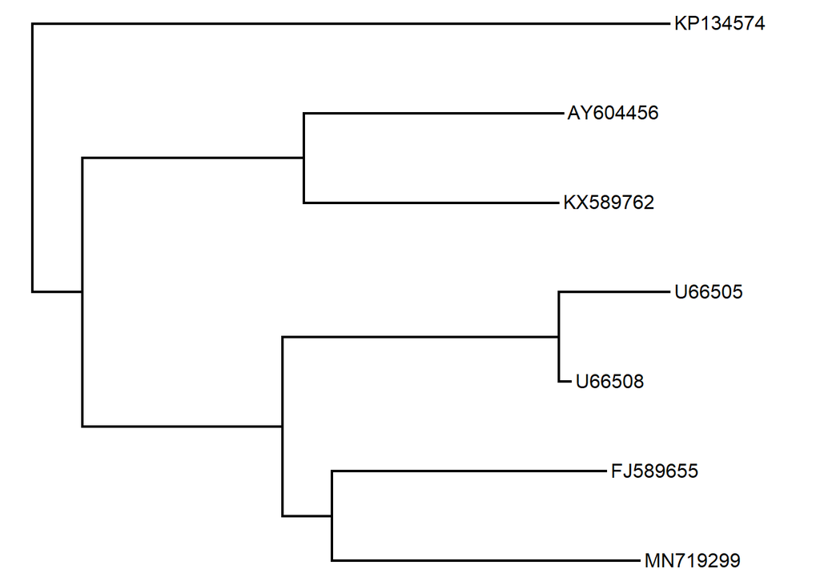

```r
plotTree(bat.tree<-untangle(midpoint(bat_mltree_unrooted),"read.tree"))
```

This tree has accession numbers instead of species labels – but we know how they’re related, so let’s update them.

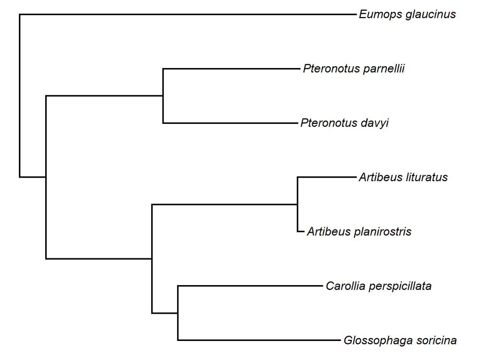

```r
spp<-setNames(names(betaAccessions),betaAccessions)
bat.tree$tip.label<-spp[bat.tree$tip.label]
plotTree(bat.tree,ftype="i")
```

Great. So far, so good.

Next, let’s do much the same with our betacoronavirus sequences. In this case, we don’t have named lineages – all we’ve got are the *GenBank* labels, so we can just keep these as our OTU names.

```r
betaCovs<-read.csv(file="betaCovs.csv")
betaCovs_seqs<-read.GenBank(betaCovs$Accession.Number)
betaCovs_seqs.aligned<-muscle5(betaCovs_seqs)
betaCovs_tree<-pml_bb(betaCovs_seqs.aligned,
  model="GTR+G(4)+I")
```

[output not shown]

[output cut: 108 more lines]

```
## optimize base frequencies:  -2992.088 --> -2992.088
## optimize rate matrix:  -2992.088 --> -2992.086
## optimize invariant sites:  -2992.086 --> -2992.079
## optimize shape parameter:  -2992.079 --> -2992.069
## optimize edge weights:  -2992.069 --> -2992.067
## optimize base frequencies:  -2992.067 --> -2992.067
## optimize rate matrix:  -2992.067 --> -2992.066
## optimize invariant sites:  -2992.066 --> -2992.059
## optimize shape parameter:  -2992.059 --> -2992.05
## optimize edge weights:  -2992.05 --> -2992.049
## optimize base frequencies:  -2992.049 --> -2992.049
## optimize rate matrix:  -2992.049 --> -2992.049
## optimize invariant sites:  -2992.049 --> -2992.044
## optimize shape parameter:  -2992.044 --> -2992.036
## optimize edge weights:  -2992.036 --> -2992.036
```

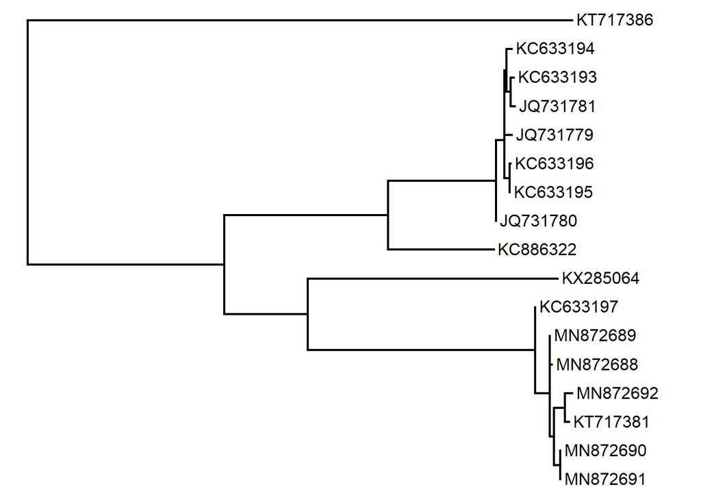

```r
plotTree(virus.tree<-untangle(midpoint(betaCovs_tree$tree),
  "read.tree"))
```

We can next build a table of associations between the taxa in our bat tree and the taxa in our virus tree. Once again, this is from the supplemental material of Caraballo (2022).

```r
assoc<-data.frame(Bats=betaCovs$Host.species,
  betaCoVs=betaCovs$Accession.Number)
assoc
```

```
##                      Bats betaCoVs
## 1  Carollia perspicillata KC633197
## 2      Artibeus lituratus KT717381
## 3   Artibeus planirostris MN872692
## 4   Artibeus planirostris MN872690
## 5   Artibeus planirostris MN872691
## 6   Artibeus planirostris MN872689
## 7   Artibeus planirostris MN872688
## 8          Glossophaginae KX285064
## 9        Pteronotus davyi KC886322
## 10   Pteronotus parnellii JQ731780
## 11   Pteronotus parnellii JQ731779
## 12   Pteronotus parnellii JQ731781
## 13   Pteronotus parnellii KC633193
## 14   Pteronotus parnellii KC633194
## 15   Pteronotus parnellii KC633195
## 16   Pteronotus parnellii KC633196
## 17       Eumops glaucinus KT717386
```

One thing I noticed right away is that the tip labeled `"Glossophaga soricina"` in the tree is actually coded by the subfamily, `"Glossophaginae"`, in our association table.

```r
assoc[assoc$Bats=="Glossophaginae",1]<-"Glossophaga soricina"
```

```r
obj<-cophylo(bat.tree,virus.tree,assoc=assoc)
```

```
## Rotating nodes to optimize matching...
## Done.
```

```r
obj
```

```
## Object of class "cophylo" containing:
##
## (1) 2 (possibly rotated) phylogenetic trees in an object of class "multiPhylo".
##
## (2) A table of associations between the tips of both trees.
```

We’re done!

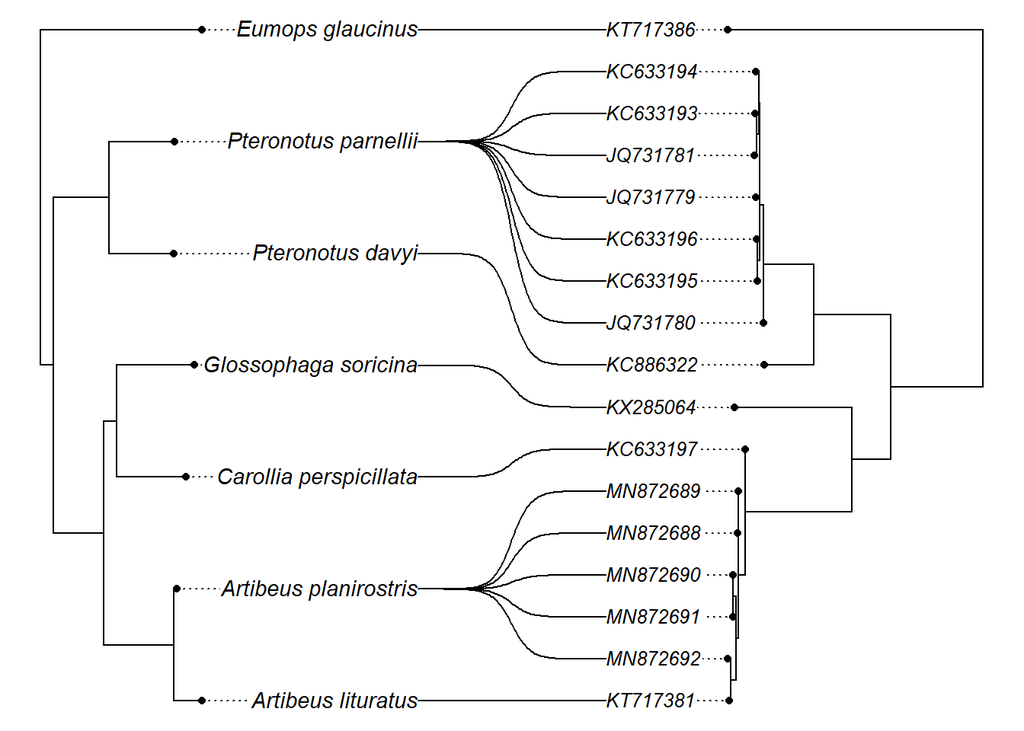

```r
plot(obj,link.lty="solid",link.type="curved",fsize=c(0.9,0.8))
```